# Analyzing Aviation Occurrences in Brazil

# Initial Data Exploration

Train the dataset.

```python
train = (df_data_1)
```

Getting the shape of Train dataset

```python
print("Train dataset's Shape:")
print(train.shape)
train.head()
```

```
Train dataset's Shape:
(2043, 23)
```

|  | Unnamed: 0 | aircraft id | occurrence id | registration | operator id | equipment | manufacturer | model | engine type | engines amount | ... | registration country | registration category | registration aviation | origin flight | destination flight | operation phase | type operation | damage level | fatalities amount | extraction day |
| --- | --- | --- | --- | --- | --- | --- | --- | --- | --- | --- | --- | --- | --- | --- | --- | --- | --- | --- | --- | --- | --- |
| 0 | 0 | 4 | 45602 | PPGXE | 241 | AIRPLANE | NEIVA INDUSTRIA AERONAUTICA | 56-C | PISTON | 1.0 | ... | BRAZIL | PRI | INSTRUCTION | SDPW | SDPW | UNKNOWN | INSTRUCTION | SUBSTANTIAL | NaN | 7/30/2016 |
| 1 | 1 | 40 | 53551 | PPGSZ | 160 | AIRPLANE | NEIVA INDUSTRIA AERONAUTICA | 56-C | PISTON | 1.0 | ... | BRAZIL | PRI | INSTRUCTION | SBBP | SBBP | TAKEOFF | INSTRUCTION | LIGHT | NaN | 7/30/2016 |
| 2 | 2 | 118 | 43721 | PTCMT | 1232 | AIRPLANE | BEECH AIRCRAFT | 95-B55 | PISTON | 2.0 | ... | BRAZIL | TPX | AEROTAXI | NaN | NaN | RUN AFTER LANDING | AEROTAXI | SUBSTANTIAL | NaN | 7/30/2016 |
| 3 | 3 | 130 | 35556 | PTEQI | 3992 | AIRPLANE | NEIVA INDUSTRIA AERONAUTICA | EMB-721C | PISTON | 1.0 | ... | BRAZIL | TPP | PRIVATE | SNDU | SBSL | RUN AFTER LANDING | PRIVATE | LIGHT | NaN | 7/30/2016 |
| 4 | 4 | 191 | 32579 | PPVMM | 4365 | AIRPLANE | BOEING COMPANY | 737-241 | JET | 2.0 | ... | BRAZIL | TPR | REGULAR | NaN | NaN | ASCENSION | REGULAR | NONE | NaN | 7/30/2016 |

5 rows × 23 columns

Getting the column names:

```python
df_data_1.columns
```

```
Index(['Unnamed: 0', 'aircraft id', 'occurrence id', 'registration',
       'operator id', 'equipment', 'manufacturer', 'model', 'engine type',
       'engines amount', 'takeoff max weight (Lbs)', 'seatings amount',
       'year manufacture', 'registration country', 'registration category',
       'registration aviation', 'origin flight', 'destination flight',
       'operation phase', 'type operation', 'damage level',
       'fatalities amount', 'extraction day'],
      dtype='object')
```

```python
df_data_1.head()
```

|  | Unnamed: 0 | aircraft id | occurrence id | registration | operator id | equipment | manufacturer | model | engine type | engines amount | ... | registration country | registration category | registration aviation | origin flight | destination flight | operation phase | type operation | damage level | fatalities amount | extraction day |
| --- | --- | --- | --- | --- | --- | --- | --- | --- | --- | --- | --- | --- | --- | --- | --- | --- | --- | --- | --- | --- | --- |
| 0 | 0 | 4 | 45602 | PPGXE | 241 | AIRPLANE | NEIVA INDUSTRIA AERONAUTICA | 56-C | PISTON | 1.0 | ... | BRAZIL | PRI | INSTRUCTION | SDPW | SDPW | UNKNOWN | INSTRUCTION | SUBSTANTIAL | NaN | 7/30/2016 |
| 1 | 1 | 40 | 53551 | PPGSZ | 160 | AIRPLANE | NEIVA INDUSTRIA AERONAUTICA | 56-C | PISTON | 1.0 | ... | BRAZIL | PRI | INSTRUCTION | SBBP | SBBP | TAKEOFF | INSTRUCTION | LIGHT | NaN | 7/30/2016 |
| 2 | 2 | 118 | 43721 | PTCMT | 1232 | AIRPLANE | BEECH AIRCRAFT | 95-B55 | PISTON | 2.0 | ... | BRAZIL | TPX | AEROTAXI | NaN | NaN | RUN AFTER LANDING | AEROTAXI | SUBSTANTIAL | NaN | 7/30/2016 |
| 3 | 3 | 130 | 35556 | PTEQI | 3992 | AIRPLANE | NEIVA INDUSTRIA AERONAUTICA | EMB-721C | PISTON | 1.0 | ... | BRAZIL | TPP | PRIVATE | SNDU | SBSL | RUN AFTER LANDING | PRIVATE | LIGHT | NaN | 7/30/2016 |
| 4 | 4 | 191 | 32579 | PPVMM | 4365 | AIRPLANE | BOEING COMPANY | 737-241 | JET | 2.0 | ... | BRAZIL | TPR | REGULAR | NaN | NaN | ASCENSION | REGULAR | NONE | NaN | 7/30/2016 |

5 rows × 23 columns

Checking the descriptive statistics for each feature

```python
df_data_1.describe()
```

|  | Unnamed: 0 | aircraft id | occurrence id | operator id | engines amount | takeoff max weight (Lbs) | seatings amount | year manufacture | fatalities amount |
| --- | --- | --- | --- | --- | --- | --- | --- | --- | --- |
| count | 2043.00000 | 2043.000000 | 2043.000000 | 2043.000000 | 2034.000000 | 2043.000000 | 2025.000000 | 2039.000000 | 355.000000 |
| mean | 1021.00000 | 12300.670093 | 43961.869799 | 3156.447871 | 1.244346 | 11750.045032 | 8.928889 | 1902.494850 | 3.208451 |
| std | 589.90762 | 7654.268691 | 7857.658738 | 1645.351104 | 0.483653 | 48511.565643 | 26.922299 | 402.024605 | 13.367108 |
| min | 0.00000 | 4.000000 | 25799.000000 | 13.000000 | 0.000000 | 0.000000 | 0.000000 | 0.000000 | 1.000000 |
| 25% | 510.50000 | 9061.000000 | 38839.500000 | 1821.000000 | 1.000000 | 1860.000000 | 2.000000 | 1975.000000 | 1.000000 |
| 50% | 1021.00000 | 11267.000000 | 45564.000000 | 3992.000000 | 1.000000 | 3600.000000 | 4.000000 | 1986.000000 | 2.000000 |
| 75% | 1531.50000 | 13601.500000 | 50353.500000 | 3992.000000 | 2.000000 | 4750.000000 | 6.000000 | 1999.000000 | 2.000000 |
| max | 2042.00000 | 39147.000000 | 65312.000000 | 6270.000000 | 4.000000 | 630499.000000 | 301.000000 | 2015.000000 | 199.000000 |

```python
train.info()
```

```
<class 'pandas.core.frame.DataFrame'>
RangeIndex: 2043 entries, 0 to 2042
Data columns (total 23 columns):
Unnamed: 0                  2043 non-null int64
aircraft id                 2043 non-null int64
occurrence id               2043 non-null int64
registration                2043 non-null object
operator id                 2043 non-null int64
equipment                   2042 non-null object
manufacturer                1933 non-null object
model                       2028 non-null object
engine type                 2043 non-null object
engines amount              2034 non-null float64
takeoff max weight (Lbs)    2043 non-null int64
seatings amount             2025 non-null float64
year manufacture            2039 non-null float64
registration country        2031 non-null object
registration category       2034 non-null object
registration aviation       2043 non-null object
origin flight               933 non-null object
destination flight          839 non-null object
operation phase             2042 non-null object
type operation              2043 non-null object
damage level                2043 non-null object
fatalities amount           355 non-null float64
extraction day              2043 non-null object
dtypes: float64(4), int64(5), object(14)
memory usage: 367.2+ KB
```

# Data Preparation

Now we will be accessing, organizing, and structuring of unprocessed data assets to be used for data analysis.

Notice that some column names contain spaces, we will replace all spaces with underlines.

```python
# Replace
df_data_1.columns = [c.replace(' ', '_') for c in df_data_1.columns]
df_data_1.head()
```

|  | Unnamed:_0 | aircraft_id | occurrence_id | registration | operator_id | equipment | manufacturer | model | engine_type | engines_amount | ... | registration_country | registration_category | registration_aviation | origin_flight | destination_flight | operation_phase | type_operation | damage_level | fatalities_amount | extraction_day |
| --- | --- | --- | --- | --- | --- | --- | --- | --- | --- | --- | --- | --- | --- | --- | --- | --- | --- | --- | --- | --- | --- |
| 0 | 0 | 4 | 45602 | PPGXE | 241 | AIRPLANE | NEIVA INDUSTRIA AERONAUTICA | 56-C | PISTON | 1.0 | ... | BRAZIL | PRI | INSTRUCTION | SDPW | SDPW | UNKNOWN | INSTRUCTION | SUBSTANTIAL | NaN | 7/30/2016 |
| 1 | 1 | 40 | 53551 | PPGSZ | 160 | AIRPLANE | NEIVA INDUSTRIA AERONAUTICA | 56-C | PISTON | 1.0 | ... | BRAZIL | PRI | INSTRUCTION | SBBP | SBBP | TAKEOFF | INSTRUCTION | LIGHT | NaN | 7/30/2016 |
| 2 | 2 | 118 | 43721 | PTCMT | 1232 | AIRPLANE | BEECH AIRCRAFT | 95-B55 | PISTON | 2.0 | ... | BRAZIL | TPX | AEROTAXI | NaN | NaN | RUN AFTER LANDING | AEROTAXI | SUBSTANTIAL | NaN | 7/30/2016 |
| 3 | 3 | 130 | 35556 | PTEQI | 3992 | AIRPLANE | NEIVA INDUSTRIA AERONAUTICA | EMB-721C | PISTON | 1.0 | ... | BRAZIL | TPP | PRIVATE | SNDU | SBSL | RUN AFTER LANDING | PRIVATE | LIGHT | NaN | 7/30/2016 |
| 4 | 4 | 191 | 32579 | PPVMM | 4365 | AIRPLANE | BOEING COMPANY | 737-241 | JET | 2.0 | ... | BRAZIL | TPR | REGULAR | NaN | NaN | ASCENSION | REGULAR | NONE | NaN | 7/30/2016 |

5 rows × 23 columns

# Data Exploration with matplotlib

Import matplotlib, define your own style and plot the results for a better data visualization.

```python
# Plotting with matplotlib
import matplotlib
import matplotlib.pyplot as plt
import plotly.graph_objs as go
import plotly.offline as pyo
import plotly.plotly as py
from plotly.graph_objs import *
pyo.offline.init_notebook_mode()
import warnings
warnings.filterwarnings('ignore')
pd.options.display.max_columns = 30
%matplotlib inline

# Defining your own style
plt.style.use('ggplot')
plt.rcParams['axes.titlesize'] = 18
plt.rcParams['axes.labelsize'] = 16
plt.rcParams['lines.linewidth'] = 7
plt.rcParams['lines.markersize'] = 14
plt.rcParams['xtick.labelsize'] = 16
plt.rcParams['ytick.labelsize'] = 16
plt.rcParams['legend.fontsize'] = 18
```

As an example, we will check the count of the aircrafts that had any sort of failure, grouping by model and engine_type, we will be able to plot the top 20 failed aircrafts.

```python
FlightsOccur_Sorted = pd.DataFrame(df_data_1.groupby(by=['model','engine_type'])['equipment'].count().reset_index())
FlightsOccur_Sorted.columns = ['model','engine_type','Count']
FlightsOccur_Sorted = FlightsOccur_Sorted.sort_values(by='Count',ascending=False)
data=[]
FlightsOccur_Sorted_Top=FlightsOccur_Sorted.iloc[:20,:]
for Airname in list(FlightsOccur_Sorted_Top['engine_type'].unique()):
    data.append(go.Bar(
    x = list(FlightsOccur_Sorted_Top[FlightsOccur_Sorted_Top['engine_type']==Airname]['model']),
    y = list(FlightsOccur_Sorted_Top[FlightsOccur_Sorted_Top['engine_type']==Airname]['Count']),
    name= Airname
    )
    )
layout = go.Layout(
    barmode='group',
    title = 'Top 20 failed Aircrafts'
)
fig = go.Figure(data=data, layout=layout)
pyo.iplot(fig)
```

[interactive chart not shown]

Clearly, we can see that model 'AB-115' that uses PISTON engines was the top failed Aircraft, followed by models 'EMB-202', 'EMB-201A' and others as you can see above.

# Scoring Data

In machine learning, also called Prediction, Scoring is the process of applying an algorithmic model built from a historical dataset to a new dataset in order to uncover practical insights that will help solving problems.

Taking as an example, the damage_level column by having the values UNKNOWN, NONE, LIGHT, SUBSTANTIAL and DESTROYED. We will score the values to nan, 0, 1, 2, 3 respectively.

```python
# Scoring
df_data_1.replace(to_replace=['UNKNOWN', 'NONE', 'LIGHT', 'SUBSTANTIAL', 'DESTROYED'], value=[np.nan, 0, 1, 2, 3], inplace=True)
df_data_1.head()
```

|  | Unnamed:_0 | aircraft_id | occurrence_id | registration | operator_id | equipment | manufacturer | model | engine_type | engines_amount | takeoff_max_weight_(Lbs) | seatings_amount | year_manufacture | registration_country | registration_category | registration_aviation | origin_flight | destination_flight | operation_phase | type_operation | damage_level | fatalities_amount | extraction_day |
| --- | --- | --- | --- | --- | --- | --- | --- | --- | --- | --- | --- | --- | --- | --- | --- | --- | --- | --- | --- | --- | --- | --- | --- |
| 0 | 0 | 4 | 45602 | PPGXE | 241 | AIRPLANE | NEIVA INDUSTRIA AERONAUTICA | 56-C | PISTON | 1.0 | 1455 | 2.0 | 1962.0 | BRAZIL | PRI | INSTRUCTION | SDPW | SDPW | NaN | INSTRUCTION | 2.0 | NaN | 7/30/2016 |
| 1 | 1 | 40 | 53551 | PPGSZ | 160 | AIRPLANE | NEIVA INDUSTRIA AERONAUTICA | 56-C | PISTON | 1.0 | 1455 | 2.0 | 1960.0 | BRAZIL | PRI | INSTRUCTION | SBBP | SBBP | TAKEOFF | INSTRUCTION | 1.0 | NaN | 7/30/2016 |
| 2 | 2 | 118 | 43721 | PTCMT | 1232 | AIRPLANE | BEECH AIRCRAFT | 95-B55 | PISTON | 2.0 | 5092 | 6.0 | 1966.0 | BRAZIL | TPX | AEROTAXI | NaN | NaN | RUN AFTER LANDING | AEROTAXI | 2.0 | NaN | 7/30/2016 |
| 3 | 3 | 130 | 35556 | PTEQI | 3992 | AIRPLANE | NEIVA INDUSTRIA AERONAUTICA | EMB-721C | PISTON | 1.0 | 3600 | 6.0 | 1979.0 | BRAZIL | TPP | PRIVATE | SNDU | SBSL | RUN AFTER LANDING | PRIVATE | 1.0 | NaN | 7/30/2016 |
| 4 | 4 | 191 | 32579 | PPVMM | 4365 | AIRPLANE | BOEING COMPANY | 737-241 | JET | 2.0 | 115497 | 117.0 | 1975.0 | BRAZIL | TPR | REGULAR | NaN | NaN | ASCENSION | REGULAR | 0.0 | NaN | 7/30/2016 |

```python
# Drop all rows where 'damage_level' & 'engines_amount' columns have NaN value
df_data_1.dropna(axis=0, how='any', subset=['damage_level', 'engines_amount'], inplace=True)
df_data_1.head()
```

|  | Unnamed:_0 | aircraft_id | occurrence_id | registration | operator_id | equipment | manufacturer | model | engine_type | engines_amount | takeoff_max_weight_(Lbs) | seatings_amount | year_manufacture | registration_country | registration_category | registration_aviation | origin_flight | destination_flight | operation_phase | type_operation | damage_level | fatalities_amount | extraction_day |
| --- | --- | --- | --- | --- | --- | --- | --- | --- | --- | --- | --- | --- | --- | --- | --- | --- | --- | --- | --- | --- | --- | --- | --- |
| 0 | 0 | 4 | 45602 | PPGXE | 241 | AIRPLANE | NEIVA INDUSTRIA AERONAUTICA | 56-C | PISTON | 1.0 | 1455 | 2.0 | 1962.0 | BRAZIL | PRI | INSTRUCTION | SDPW | SDPW | NaN | INSTRUCTION | 2.0 | NaN | 7/30/2016 |
| 1 | 1 | 40 | 53551 | PPGSZ | 160 | AIRPLANE | NEIVA INDUSTRIA AERONAUTICA | 56-C | PISTON | 1.0 | 1455 | 2.0 | 1960.0 | BRAZIL | PRI | INSTRUCTION | SBBP | SBBP | TAKEOFF | INSTRUCTION | 1.0 | NaN | 7/30/2016 |
| 2 | 2 | 118 | 43721 | PTCMT | 1232 | AIRPLANE | BEECH AIRCRAFT | 95-B55 | PISTON | 2.0 | 5092 | 6.0 | 1966.0 | BRAZIL | TPX | AEROTAXI | NaN | NaN | RUN AFTER LANDING | AEROTAXI | 2.0 | NaN | 7/30/2016 |
| 3 | 3 | 130 | 35556 | PTEQI | 3992 | AIRPLANE | NEIVA INDUSTRIA AERONAUTICA | EMB-721C | PISTON | 1.0 | 3600 | 6.0 | 1979.0 | BRAZIL | TPP | PRIVATE | SNDU | SBSL | RUN AFTER LANDING | PRIVATE | 1.0 | NaN | 7/30/2016 |
| 4 | 4 | 191 | 32579 | PPVMM | 4365 | AIRPLANE | BOEING COMPANY | 737-241 | JET | 2.0 | 115497 | 117.0 | 1975.0 | BRAZIL | TPR | REGULAR | NaN | NaN | ASCENSION | REGULAR | 0.0 | NaN | 7/30/2016 |

Let's explore a little more this Dataset and see the top 10 failed aircrafts based on the operation phases of the Occurrence to which Aircrafts and in which operation phase failed.

```python
FlightsOccur_Sorted = pd.DataFrame(df_data_1.groupby(by=['model','operation_phase'])['equipment'].count().reset_index())
FlightsOccur_Sorted.columns = ['model','operation_phase','Count']
FlightsOccur_Sorted = FlightsOccur_Sorted.sort_values(by='Count',ascending=False)
data=[]
FlightsOccur_Sorted_Top=FlightsOccur_Sorted.iloc[:10,:]
for Airname in list(FlightsOccur_Sorted_Top['operation_phase'].unique()):
    data.append(go.Bar(
    x = list(FlightsOccur_Sorted_Top[FlightsOccur_Sorted_Top['operation_phase']==Airname]['model']),
    y = list(FlightsOccur_Sorted_Top[FlightsOccur_Sorted_Top['operation_phase']==Airname]['Count']),
    name= Airname
    )
    )
layout = go.Layout(
    barmode='group',
    title = 'Top aircrafts fails based on the operation phases of the Occurrence'
)
fig = go.Figure(data=data, layout=layout)
pyo.iplot(fig)
```

[interactive chart not shown]

Curiously, only two of all aircrafts had occurrences during the 'SPECIALISED' operation phase.

Specifically, the 'AB-115' model had 34 Landing, 24 Takeoff and 15 Run After Landing occurrences.

# Import the 'occurrences.csv' dataset

We will import the "occurrences.csv" dataset into the Notebook and explore our second dataset.

```python
#Insert your pandas DataFrame by clicking 'Insert pandas DataFrame' from the drop-down of the "occurrences.csv" dataset
body = client_689c19f611b0478583c74d2a7431addc.get_object(Bucket='default-donotdelete-pr-nlfssruajbx9xv',Key='occurrences.csv')['Body']
# add missing __iter__ method, so pandas accepts body as file-like object
if not hasattr(body, "__iter__"): body.__iter__ = types.MethodType( __iter__, body )

df_data_2 = pd.read_csv(body, na_values=['****', '***',''], header=0, encoding='latin-1')
df_data_2.head()
```

|  | Unnamed: 0 | occurrence id | classification | type of occurrence | localization | fu | country | aerodrome | occurrence day | time | under investigation | investigating command | investigation status | report number | published report | publication day | recommendation amount | aircrafts involved | takeoff | extraction day |
| --- | --- | --- | --- | --- | --- | --- | --- | --- | --- | --- | --- | --- | --- | --- | --- | --- | --- | --- | --- | --- |
| 0 | 0 | 47965 | ACCIDENT | ENGINE FAILURE DURING THE FLIGHT | ARIQUEMES | RO | BRAZIL | SJOG | 5/5/2013 | 11:00:00 | UNKNOWN | SERIPA-7 | NaN | NaN | NaN | NaN | 0 | 1 | NaN | 7/30/2016 |
| 1 | 1 | 50313 | SERIOUS INCIDENT | LANDING WITHOUT LANDING GEAR | CACOAL | RO | BRAZIL | SSKW | 11/25/2013 | 12:32:00 | YES | SERIPA-7 | FINISHED | NaN | 1.0 | 4/7/2014 | 0 | 1 | NaN | 7/30/2016 |
| 2 | 2 | 34078 | ACCIDENT | LOSS OF CONTROL ON THE GROUND | CEREJEIRAS | RO | BRAZIL | NaN | 8/7/2008 | 15:10:00 | YES | SERIPA-7 | FINISHED | NaN | 1.0 | 7/7/2016 | 0 | 1 | 1.0 | 7/30/2016 |
| 3 | 3 | 44988 | ACCIDENT | SLOW LANDING | AMAJARI | RR | BRAZIL | NaN | 8/11/2011 | 17:00:00 | YES | SERIPA-7 | FINISHED | NaN | 1.0 | 9/20/2012 | 4 | 1 | NaN | 7/30/2016 |
| 4 | 4 | 38855 | ACCIDENT | LOSS OF CONTROL IN THE AIR | ACEGUÁ | RS | BRAZIL | NaN | 12/28/2009 | 17:30:00 | YES | SERIPA-5 | IN PROGRESS | UNDEFINED | NaN | NaN | 0 | 1 | NaN | 7/30/2016 |

# Initial Data Exploration

Test dataset

```python
test = (df_data_2)
```

Getting the shape of Test dataset

```python
print("Test dataset's shape:")
print(test.shape)
test.head()
```

```
Test dataset's shape:
(2027, 20)
```

|  | Unnamed: 0 | occurrence id | classification | type of occurrence | localization | fu | country | aerodrome | occurrence day | time | under investigation | investigating command | investigation status | report number | published report | publication day | recommendation amount | aircrafts involved | takeoff | extraction day |
| --- | --- | --- | --- | --- | --- | --- | --- | --- | --- | --- | --- | --- | --- | --- | --- | --- | --- | --- | --- | --- |
| 0 | 0 | 47965 | ACCIDENT | ENGINE FAILURE DURING THE FLIGHT | ARIQUEMES | RO | BRAZIL | SJOG | 5/5/2013 | 11:00:00 | UNKNOWN | SERIPA-7 | NaN | NaN | NaN | NaN | 0 | 1 | NaN | 7/30/2016 |
| 1 | 1 | 50313 | SERIOUS INCIDENT | LANDING WITHOUT LANDING GEAR | CACOAL | RO | BRAZIL | SSKW | 11/25/2013 | 12:32:00 | YES | SERIPA-7 | FINISHED | NaN | 1.0 | 4/7/2014 | 0 | 1 | NaN | 7/30/2016 |
| 2 | 2 | 34078 | ACCIDENT | LOSS OF CONTROL ON THE GROUND | CEREJEIRAS | RO | BRAZIL | NaN | 8/7/2008 | 15:10:00 | YES | SERIPA-7 | FINISHED | NaN | 1.0 | 7/7/2016 | 0 | 1 | 1.0 | 7/30/2016 |
| 3 | 3 | 44988 | ACCIDENT | SLOW LANDING | AMAJARI | RR | BRAZIL | NaN | 8/11/2011 | 17:00:00 | YES | SERIPA-7 | FINISHED | NaN | 1.0 | 9/20/2012 | 4 | 1 | NaN | 7/30/2016 |
| 4 | 4 | 38855 | ACCIDENT | LOSS OF CONTROL IN THE AIR | ACEGUÁ | RS | BRAZIL | NaN | 12/28/2009 | 17:30:00 | YES | SERIPA-5 | IN PROGRESS | UNDEFINED | NaN | NaN | 0 | 1 | NaN | 7/30/2016 |

Getting the columns names

```python
df_data_2.columns
```

```
Index(['Unnamed: 0', 'occurrence id', 'classification', 'type of occurrence',
       'localization', 'fu', 'country', 'aerodrome', 'occurrence day', 'time',
       'under investigation', 'investigating command', 'investigation status',
       'report number', 'published report', 'publication day',
       'recommendation amount', 'aircrafts involved', 'takeoff',
       'extraction day'],
      dtype='object')
```

```python
df_data_2.head()
```

|  | Unnamed: 0 | occurrence id | classification | type of occurrence | localization | fu | country | aerodrome | occurrence day | time | under investigation | investigating command | investigation status | report number | published report | publication day | recommendation amount | aircrafts involved | takeoff | extraction day |
| --- | --- | --- | --- | --- | --- | --- | --- | --- | --- | --- | --- | --- | --- | --- | --- | --- | --- | --- | --- | --- |
| 0 | 0 | 47965 | ACCIDENT | ENGINE FAILURE DURING THE FLIGHT | ARIQUEMES | RO | BRAZIL | SJOG | 5/5/2013 | 11:00:00 | UNKNOWN | SERIPA-7 | NaN | NaN | NaN | NaN | 0 | 1 | NaN | 7/30/2016 |
| 1 | 1 | 50313 | SERIOUS INCIDENT | LANDING WITHOUT LANDING GEAR | CACOAL | RO | BRAZIL | SSKW | 11/25/2013 | 12:32:00 | YES | SERIPA-7 | FINISHED | NaN | 1.0 | 4/7/2014 | 0 | 1 | NaN | 7/30/2016 |
| 2 | 2 | 34078 | ACCIDENT | LOSS OF CONTROL ON THE GROUND | CEREJEIRAS | RO | BRAZIL | NaN | 8/7/2008 | 15:10:00 | YES | SERIPA-7 | FINISHED | NaN | 1.0 | 7/7/2016 | 0 | 1 | 1.0 | 7/30/2016 |
| 3 | 3 | 44988 | ACCIDENT | SLOW LANDING | AMAJARI | RR | BRAZIL | NaN | 8/11/2011 | 17:00:00 | YES | SERIPA-7 | FINISHED | NaN | 1.0 | 9/20/2012 | 4 | 1 | NaN | 7/30/2016 |
| 4 | 4 | 38855 | ACCIDENT | LOSS OF CONTROL IN THE AIR | ACEGUÁ | RS | BRAZIL | NaN | 12/28/2009 | 17:30:00 | YES | SERIPA-5 | IN PROGRESS | UNDEFINED | NaN | NaN | 0 | 1 | NaN | 7/30/2016 |

Checking the descriptive statistics for each feature

```python
df_data_2.describe()
```

|  | Unnamed: 0 | occurrence id | published report | recommendation amount | aircrafts involved | takeoff |
| --- | --- | --- | --- | --- | --- | --- |
| count | 2027.000000 | 2027.000000 | 995.000000 | 2027.000000 | 2027.000000 | 256.000000 |
| mean | 1013.000000 | 43942.818451 | 0.993970 | 1.141095 | 1.007893 | 0.968750 |
| std | 585.288818 | 7863.305498 | 0.077458 | 3.571001 | 0.103906 | 0.174333 |
| min | 0.000000 | 25799.000000 | 0.000000 | 0.000000 | 1.000000 | 0.000000 |
| 25% | 506.500000 | 38839.500000 | 1.000000 | 0.000000 | 1.000000 | 1.000000 |
| 50% | 1013.000000 | 45554.000000 | 1.000000 | 0.000000 | 1.000000 | 1.000000 |
| 75% | 1519.500000 | 50347.500000 | 1.000000 | 1.000000 | 1.000000 | 1.000000 |
| max | 2026.000000 | 65312.000000 | 1.000000 | 83.000000 | 4.000000 | 1.000000 |

```python
test.info()
```

```
<class 'pandas.core.frame.DataFrame'>
RangeIndex: 2027 entries, 0 to 2026
Data columns (total 20 columns):
Unnamed: 0               2027 non-null int64
occurrence id            2027 non-null int64
classification           2027 non-null object
type of occurrence       2027 non-null object
localization             2027 non-null object
fu                       2025 non-null object
country                  2027 non-null object
aerodrome                807 non-null object
occurrence day           2027 non-null object
time                     2027 non-null object
under investigation      2027 non-null object
investigating command    2027 non-null object
investigation status     1821 non-null object
report number            433 non-null object
published report         995 non-null float64
publication day          995 non-null object
recommendation amount    2027 non-null int64
aircrafts involved       2027 non-null int64
takeoff                  256 non-null float64
extraction day           2027 non-null object
dtypes: float64(2), int64(4), object(14)
memory usage: 316.8+ KB
```

# Data preparation

Notice that some column names contain spaces, we will also replace every space with an underline.

```python
# Replace
df_data_2.columns = [c.replace(' ', '_') for c in df_data_2.columns]
df_data_2.head()
```

|  | Unnamed:_0 | occurrence_id | classification | type_of_occurrence | localization | fu | country | aerodrome | occurrence_day | time | under_investigation | investigating_command | investigation_status | report_number | published_report | publication_day | recommendation_amount | aircrafts_involved | takeoff | extraction_day |
| --- | --- | --- | --- | --- | --- | --- | --- | --- | --- | --- | --- | --- | --- | --- | --- | --- | --- | --- | --- | --- |
| 0 | 0 | 47965 | ACCIDENT | ENGINE FAILURE DURING THE FLIGHT | ARIQUEMES | RO | BRAZIL | SJOG | 5/5/2013 | 11:00:00 | UNKNOWN | SERIPA-7 | NaN | NaN | NaN | NaN | 0 | 1 | NaN | 7/30/2016 |
| 1 | 1 | 50313 | SERIOUS INCIDENT | LANDING WITHOUT LANDING GEAR | CACOAL | RO | BRAZIL | SSKW | 11/25/2013 | 12:32:00 | YES | SERIPA-7 | FINISHED | NaN | 1.0 | 4/7/2014 | 0 | 1 | NaN | 7/30/2016 |
| 2 | 2 | 34078 | ACCIDENT | LOSS OF CONTROL ON THE GROUND | CEREJEIRAS | RO | BRAZIL | NaN | 8/7/2008 | 15:10:00 | YES | SERIPA-7 | FINISHED | NaN | 1.0 | 7/7/2016 | 0 | 1 | 1.0 | 7/30/2016 |
| 3 | 3 | 44988 | ACCIDENT | SLOW LANDING | AMAJARI | RR | BRAZIL | NaN | 8/11/2011 | 17:00:00 | YES | SERIPA-7 | FINISHED | NaN | 1.0 | 9/20/2012 | 4 | 1 | NaN | 7/30/2016 |
| 4 | 4 | 38855 | ACCIDENT | LOSS OF CONTROL IN THE AIR | ACEGUÁ | RS | BRAZIL | NaN | 12/28/2009 | 17:30:00 | YES | SERIPA-5 | IN PROGRESS | UNDEFINED | NaN | NaN | 0 | 1 | NaN | 7/30/2016 |

As an example, we will create a new column called 'occurrence_year' and extract the year from 'occurrence_day' column, which is composed of Month, Day and Year.

```python
# Create a new column called 'occurrence_year' based on the 'occurrence_day' column
df_data_2['occurrence_year'] = pd.to_datetime(df_data_2['occurrence_day'], format='%m/%d/%Y').dt.year
df_data_2.head()
```

|  | Unnamed:_0 | occurrence_id | classification | type_of_occurrence | localization | fu | country | aerodrome | occurrence_day | time | under_investigation | investigating_command | investigation_status | report_number | published_report | publication_day | recommendation_amount | aircrafts_involved | takeoff | extraction_day | occurrence_year |
| --- | --- | --- | --- | --- | --- | --- | --- | --- | --- | --- | --- | --- | --- | --- | --- | --- | --- | --- | --- | --- | --- |
| 0 | 0 | 47965 | ACCIDENT | ENGINE FAILURE DURING THE FLIGHT | ARIQUEMES | RO | BRAZIL | SJOG | 5/5/2013 | 11:00:00 | UNKNOWN | SERIPA-7 | NaN | NaN | NaN | NaN | 0 | 1 | NaN | 7/30/2016 | 2013 |
| 1 | 1 | 50313 | SERIOUS INCIDENT | LANDING WITHOUT LANDING GEAR | CACOAL | RO | BRAZIL | SSKW | 11/25/2013 | 12:32:00 | YES | SERIPA-7 | FINISHED | NaN | 1.0 | 4/7/2014 | 0 | 1 | NaN | 7/30/2016 | 2013 |
| 2 | 2 | 34078 | ACCIDENT | LOSS OF CONTROL ON THE GROUND | CEREJEIRAS | RO | BRAZIL | NaN | 8/7/2008 | 15:10:00 | YES | SERIPA-7 | FINISHED | NaN | 1.0 | 7/7/2016 | 0 | 1 | 1.0 | 7/30/2016 | 2008 |
| 3 | 3 | 44988 | ACCIDENT | SLOW LANDING | AMAJARI | RR | BRAZIL | NaN | 8/11/2011 | 17:00:00 | YES | SERIPA-7 | FINISHED | NaN | 1.0 | 9/20/2012 | 4 | 1 | NaN | 7/30/2016 | 2011 |
| 4 | 4 | 38855 | ACCIDENT | LOSS OF CONTROL IN THE AIR | ACEGUÁ | RS | BRAZIL | NaN | 12/28/2009 | 17:30:00 | YES | SERIPA-5 | IN PROGRESS | UNDEFINED | NaN | NaN | 0 | 1 | NaN | 7/30/2016 | 2009 |

# Data Analysis and Classification

Classification can be performed on structured or unstructured data. Classification is a technique where we categorize data into a given number of classes. The main goal of a classification problem is to identify the category/class to which a new data will fall under.

```python
# Classification
print(df_data_2['classification'].unique())
```

```
['ACCIDENT' 'SERIOUS INCIDENT']
```

Now we will get the count of 'ACCIDENT' and 'SERIOUS INCIDENT' and also the total count

```python
# Count
print('Total: ' + str(df_data_2['classification'].count()))
print('SERIOUS INCIDENT: ' + str(df_data_2['classification'][df_data_2['classification'] == 'SERIOUS INCIDENT'].count()))
print('ACCIDENT: ' + str(df_data_2['classification'][df_data_2['classification'] == 'ACCIDENT'].count()))
```

```
Total: 2027
SERIOUS INCIDENT: 552
ACCIDENT: 1475
```

List all Occurrece Types

```python
# List all occurrence types
print(df_data_2['type_of_occurrence'].unique())
```

```
['ENGINE FAILURE DURING THE FLIGHT' 'LANDING WITHOUT LANDING GEAR'
 'LOSS OF CONTROL ON THE GROUND' 'SLOW LANDING'
 'LOSS OF CONTROL IN THE AIR' 'UNKNOWN' 'ABOUT LANDING GEAR'
 'TERRAIN COLLISION' 'TRACK INCURSION'
 'METEOROLOGICAL PHENOMENOM IN THE AIR' 'HARD LANDING' 'ANOTHER TYPES'
 'ABOUT ROTOR' 'SYSTEM / COMPONENT FAILURE'
 'COLLISION AGAINST OBSTACLE DURING THE FLIGHT'
 'ABOUT WINDOWS / DOORS / WINDSHIELD' 'LOSS OF COMPONENT DURING THE FLIGHT'
 'COLLISION AGAINST OBSTACLE ON THE GROUND' 'FIRE DURING THE FLIGHT'
 'LANDING BEFORE THE TRACK AREA' 'LOAD LAUNCH'
 'EXPLOSIVE / NOT INTENTIONAL DECOMPRESSION'
 'AIRCRAFTS COLLISION IN THE AIR' 'SPATIAL UNAWARENESS'
 'LANDING ON UNPREDICTABLE PLACE' 'TIRE BURST' 'FUEL STARVATION'
 'COMPONENT LOSS ON THE GROUND' 'ABOUT PROPELLER' 'LOW ALTITUDE MANEUVERS'
 'FIRE ON THE GROUND' 'VEHICLE COLLISION AGAINST AIRCRAFT'
 'FOD - DAMAGE CAUSED BY UNKNOWN OBJECT'
 'COLLISION DURING THE FLIGHT AGAINST TOWED OBJECT'
 'AIRCRAFT HIT BY OBJECT' 'METEOROLOGICAL PHENOMENOM ON THE GROUND'
 'AIRCRAFTS COLLISION ON THE GROUND' 'STRUCTURAL FAILURE' 'AIR TRAFFIC'
 'FLIGHT COMMANDS' 'FLUID LEAKS' 'SMOKE IN THE CABIN' 'LEAVING THE TRACK'
 'ABOUT PASSENGERS/CREW DURING THE FLIGHT' 'INVOLUNTARY ENGINE CUT OFF'
 'PHYSIOLOGICAL PROBLEMS' 'PEOPLE LAUNCH' 'COLLISION AGAINST BIRD'
 'ENGINE FAILURE IN THE GROUND']
```

Also get the count of each occurrence type

```python
# Count of each occurrence type
for occ in df_data_2['type_of_occurrence'].unique():
    print(occ + ': ' + str(df_data_2['type_of_occurrence'][df_data_2['type_of_occurrence'] == occ].count()))
```

```
ENGINE FAILURE DURING THE FLIGHT: 377
LANDING WITHOUT LANDING GEAR: 54
LOSS OF CONTROL ON THE GROUND: 325
SLOW LANDING: 30
LOSS OF CONTROL IN THE AIR: 310
UNKNOWN: 57
ABOUT LANDING GEAR: 130
TERRAIN COLLISION: 21
TRACK INCURSION: 1
METEOROLOGICAL PHENOMENOM IN THE AIR: 27
HARD LANDING: 40
ANOTHER TYPES: 87
ABOUT ROTOR: 3
SYSTEM / COMPONENT FAILURE: 61
COLLISION AGAINST OBSTACLE DURING THE FLIGHT: 142
ABOUT WINDOWS / DOORS / WINDSHIELD: 5
LOSS OF COMPONENT DURING THE FLIGHT: 27
COLLISION AGAINST OBSTACLE ON THE GROUND: 40
FIRE DURING THE FLIGHT: 8
LANDING BEFORE THE TRACK AREA: 15
LOAD LAUNCH: 1
EXPLOSIVE / NOT INTENTIONAL DECOMPRESSION: 9
AIRCRAFTS COLLISION IN THE AIR: 6
SPATIAL UNAWARENESS: 10
LANDING ON UNPREDICTABLE PLACE: 44
TIRE BURST: 14
FUEL STARVATION: 74
COMPONENT LOSS ON THE GROUND: 6
ABOUT PROPELLER: 11
LOW ALTITUDE MANEUVERS: 16
FIRE ON THE GROUND: 7
VEHICLE COLLISION AGAINST AIRCRAFT: 1
FOD - DAMAGE CAUSED BY UNKNOWN OBJECT: 1
COLLISION DURING THE FLIGHT AGAINST TOWED OBJECT: 1
AIRCRAFT HIT BY OBJECT: 2
METEOROLOGICAL PHENOMENOM ON THE GROUND: 3
AIRCRAFTS COLLISION ON THE GROUND: 8
STRUCTURAL FAILURE: 7
AIR TRAFFIC: 10
FLIGHT COMMANDS: 8
FLUID LEAKS: 6
SMOKE IN THE CABIN: 1
LEAVING THE TRACK: 5
ABOUT PASSENGERS/CREW DURING THE FLIGHT: 2
INVOLUNTARY ENGINE CUT OFF: 3
PHYSIOLOGICAL PROBLEMS: 2
PEOPLE LAUNCH: 1
COLLISION AGAINST BIRD: 5
ENGINE FAILURE IN THE GROUND: 3
```

Plot the results for a better view

```python
FlightOccur_Sorted = pd.DataFrame(df_data_2.groupby(by=['type_of_occurrence','classification'])['fu'].count().reset_index())
FlightOccur_Sorted.columns = ['type_of_occurrence','classification','Count']
FlightOccur_Sorted = FlightOccur_Sorted.sort_values(by='Count',ascending=False)
data=[]
FlightOccur_Sorted_Top=FlightOccur_Sorted.iloc[:10,:]
for Airname in list(FlightOccur_Sorted_Top['classification'].unique()):
    data.append(go.Bar(
    x = list(FlightOccur_Sorted_Top[FlightOccur_Sorted_Top['classification']==Airname]['type_of_occurrence']),
    y = list(FlightOccur_Sorted_Top[FlightOccur_Sorted_Top['classification']==Airname]['Count']),
    name= Airname
    )
    )
layout = go.Layout(
    barmode='group',
    title = 'Top 10 aircrafts fails based on the operation phases of the Occurrence'
)
fig = go.Figure(data=data, layout=layout)
pyo.iplot(fig)
```

[interactive chart not shown]

# Applying Data Normalization to the Occurrence Type field

Data normalization means transforming all variables in the data to a specific range. We do data normalization when seeking for relations.

```python
# Data Normalization
occurrences_freq_dict = {}
for occ in df_data_2['type_of_occurrence'].unique():occurrences_freq_dict[occ] = df_data_2['type_of_occurrence'][df_data_2['type_of_occurrence'] == occ].count() / df_data_2['type_of_occurrence'].count()
occurrences_freq = pd.Series(occurrences_freq_dict)
occurrences_freq.head(10)
```

```
ABOUT LANDING GEAR                         0.064134
ABOUT PASSENGERS/CREW DURING THE FLIGHT    0.000987
ABOUT PROPELLER                            0.005427
ABOUT ROTOR                                0.001480
ABOUT WINDOWS / DOORS / WINDSHIELD         0.002467
AIR TRAFFIC                                0.004933
AIRCRAFT HIT BY OBJECT                     0.000987
AIRCRAFTS COLLISION IN THE AIR             0.002960
AIRCRAFTS COLLISION ON THE GROUND          0.003947
ANOTHER TYPES                              0.042921
dtype: float64
```

# Now let's see the count for each State

Notice the "EX" isn't a state and it relates to occurrences happened outside of Brazilian territory

```python
for occ in df_data_2['fu'].unique():
    print(str(occ) + ' :' + str(df_data_2['fu'][df_data_2['fu'] == occ].count()))
```

```
RO :14
RR :25
RS :169
GO :141
RJ :120
ES :16
AL :12
DF :30
AC :14
MT :153
AM :81
PI :20
MS :72
SP :434
MA :40
AP :6
PA :119
SE :7
PR :154
CE :25
BA :83
MG :152
PE :29
RN :7
PB :6
SC :58
TO :30
nan :0
EX :8
```

# Applying Data Normalization for the States field

Database normalization is the process of structuring a relational database in accordance with a series of so-called normal forms in order to reduce data redundancy and improve data integrity.

```python
states_freq_dict = {}
for occ in df_data_2['fu'].unique():
    states_freq_dict[occ] = df_data_2['fu'][df_data_2['fu'] == occ].count() / df_data_2['fu'].count()
states_freq = pd.Series(states_freq_dict)
states_freq.head(30)
```

```
AC     0.006914
CE     0.012346
RR     0.012346
TO     0.014815
NaN    0.000000
AL     0.005926
PB     0.002963
SC     0.028642
RJ     0.059259
ES     0.007901
MA     0.019753
PR     0.076049
MS     0.035556
SP     0.214321
RO     0.006914
BA     0.040988
MG     0.075062
DF     0.014815
MT     0.075556
RN     0.003457
RS     0.083457
SE     0.003457
EX     0.003951
PI     0.009877
PE     0.014321
AP     0.002963
AM     0.040000
GO     0.069630
PA     0.058765
dtype: float64
```

# Plotting the results of Flight Occurrence rate

Now we will plot the rate results

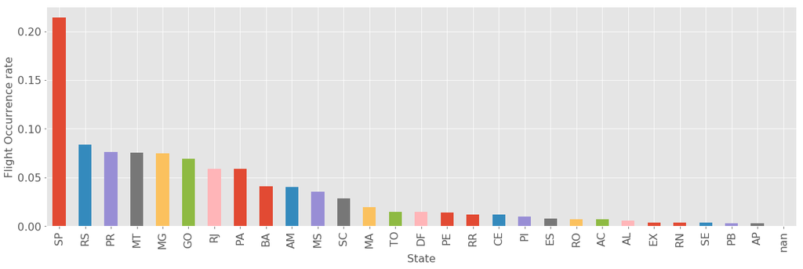

```python
fig, axes = plt.subplots(figsize=(20.,6.))
states_freq.sort_values(ascending=False).plot(kind='bar')

axes.set_xlabel('State')
axes.set_ylabel('Flight Occurrence rate')

plt.show()
plt.close()
```

Clearly we see 'SP' state as the top followed by 'RS', 'PR', 'MT', 'MG' and other as shown above.

# Flights evolution per state from 2006 to 2015

The results will show the rate for each state, also look for the 'All' column to have a better idea of the evolution

```python
freq_year_dict = { }
freq_year_dict['all'] = {}

for s in df_data_2['fu'].unique():freq_year_dict[s] = {}

for occ in df_data_2['occurrence_year'].unique():

    freq_year_dict['all'][occ] = df_data_2['occurrence_year'][df_data_2['occurrence_year'] == occ].count()

    for s in df_data_2['fu'].unique():

        freq_year_dict[s][occ] = df_data_2['occurrence_year'][(df_data_2['occurrence_year'] == occ) &(df_data_2['fu'] == s)].count()

freq_year = pd.DataFrame(freq_year_dict)

freq_year.head(10)
```

|  | AC | CE | RR | TO | nan | AL | PB | SC | RJ | ES | MA | PR | MS | SP | RO | BA | MG | DF | MT | RN | RS | SE | all | EX | PI | PE | AP | AM | GO | … |
| --- | --- | --- | --- | --- | --- | --- | --- | --- | --- | --- | --- | --- | --- | --- | --- | --- | --- | --- | --- | --- | --- | --- | --- | --- | --- | --- | --- | --- | --- | --- |
| 2006 | 0 | 1 | 2 | 0 | 0 | 2 | 0 | 5 | 7 | 3 | 2 | 10 | 3 | 22 | 1 | 1 | 6 | 4 | 8 | 1 | 11 | 0 | 117 | 2 | 1 | 1 | 1 | 9 | 7 | … |
| 2007 | 2 | 3 | 1 | 5 | 0 | 2 | 0 | 2 | 6 | 2 | 4 | 7 | 4 | 25 | 0 | 10 | 8 | 1 | 11 | 1 | 6 | 0 | 126 | 2 | 1 | 3 | 0 | 5 | 6 | … |
| 2008 | 3 | 1 | 2 | 3 | 0 | 1 | 0 | 2 | 14 | 0 | 2 | 8 | 9 | 28 | 1 | 7 | 4 | 4 | 11 | 0 | 18 | 0 | 148 | 2 | 3 | 3 | 1 | 6 | 3 | … |
| 2009 | 0 | 2 | 0 | 2 | 0 | 2 | 0 | 7 | 9 | 2 | 5 | 7 | 7 | 38 | 1 | 5 | 14 | 1 | 10 | 0 | 14 | 0 | 156 | 1 | 1 | 0 | 1 | 8 | 12 | … |
| 2010 | 1 | 2 | 5 | 5 | 0 | 2 | 0 | 5 | 13 | 0 | 5 | 15 | 5 | 33 | 1 | 10 | 13 | 4 | 16 | 0 | 16 | 1 | 194 | 0 | 1 | 5 | 1 | 4 | 15 | … |
| 2011 | 3 | 3 | 4 | 3 | 0 | 1 | 1 | 9 | 15 | 3 | 3 | 23 | 9 | 52 | 1 | 11 | 19 | 5 | 16 | 1 | 18 | 1 | 255 | 0 | 1 | 5 | 0 | 10 | 24 | … |
| 2012 | 0 | 2 | 3 | 3 | 0 | 0 | 1 | 10 | 19 | 1 | 4 | 20 | 10 | 69 | 1 | 14 | 30 | 4 | 22 | 0 | 19 | 1 | 287 | 0 | 2 | 3 | 2 | 12 | 18 | … |
| 2013 | 1 | 3 | 0 | 2 | 0 | 0 | 3 | 5 | 14 | 2 | 5 | 19 | 11 | 66 | 5 | 9 | 19 | 2 | 26 | 0 | 23 | 0 | 269 | 0 | 3 | 4 | 0 | 11 | 24 | … |
| 2014 | 4 | 4 | 4 | 4 | 0 | 0 | 0 | 4 | 10 | 1 | 5 | 22 | 9 | 58 | 0 | 9 | 19 | 3 | 18 | 1 | 25 | 2 | 252 | 0 | 5 | 4 | 0 | 9 | 15 | … |
| 2015 | 0 | 4 | 4 | 3 | 0 | 2 | 1 | 9 | 13 | 2 | 5 | 23 | 5 | 43 | 3 | 7 | 20 | 2 | 15 | 3 | 19 | 2 | 223 | 1 | 2 | 1 | 0 | 7 | 17 | … |